# BRAIN STRUCTURE HUMAN PREDICTIONS AND COMPARING COSTS TO ANATOMY

#Data preparation

### Set working directory

```r
setwd("C:\\Users\\michaelproulx\\Downloads\\1A analyses metabol rates regions\\1A analyses metabol rates regions\\R")
```

## Install and Load up packages

```r
## install.packages(c("ape", "geiger", "nlme", "caper", "car", "ggplot2", "ggrepel", "patchwork"))
library(ape)
library(geiger)
library(nlme)
library(caper)
library(car)
library(ggplot2)
library(ggrepel)
library(patchwork)
```

#PART 1: Prediction Human Brain Structure Volumes using Stephan Brain data

## Preparation

Import data and tree

```r
Data <- read.csv("Stephan_NHprimates.csv", header = TRUE)
TreePrimate <- read.tree("NHP.nwk")
row.names(Data) <- Data$Species
```

## Test the tree and data

Plot tree

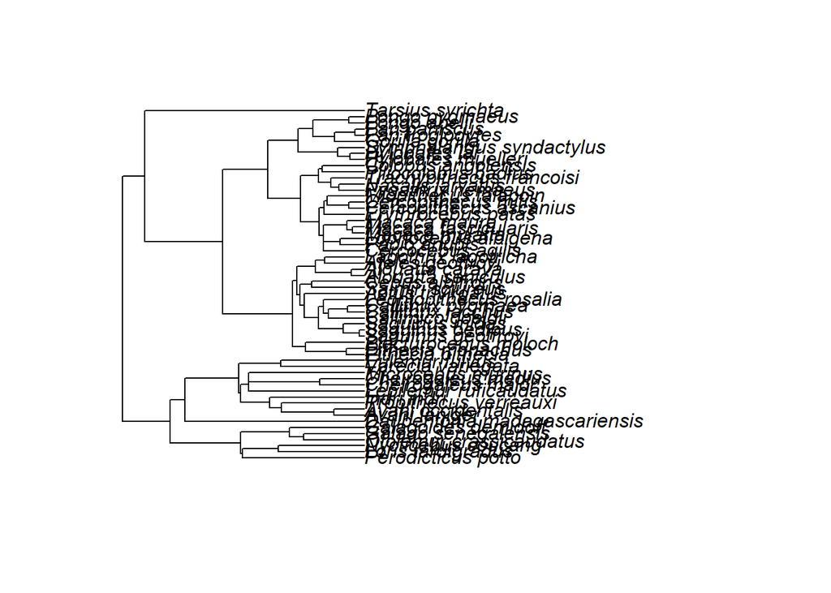

```r
plot(TreePrimate)
```

Species in the phylogeny but not in the data?

```r
setdiff(TreePrimate$tip.label, Data$Species)
```

```
## character(0)
```

Species in the data but not in the phylogeny?

```r
setdiff(Data$Species, TreePrimate$tip.label)
```

```
## character(0)
```

## Convert into factor or numerical

```r
Data$Body_weight <- as.numeric(Data$Body_weight)
Data$Brain_weight <- as.numeric(Data$Brain_weight)
Data$Ventricles <- as.numeric(Data$Ventricles)
Data$Meninges_hypophysis_nerves_etc <- as.numeric(Data$Meninges_hypophysis_nerves_etc)
Data$Total_brain_net_volume <- as.numeric(Data$Total_brain_net_volume)
Data$Medulla_oblongata <- as.numeric(Data$Medulla_oblongata)
Data$Cerebellum <- as.numeric(Data$Cerebellum)
Data$Mesencephalon <- as.numeric(Data$Mesencephalon)
Data$Diencephalon <- as.numeric(Data$Diencephalon)
Data$Telencephalon <- as.numeric(Data$Telencephalon)
Data$Bulbus_olfactorius <- as.numeric(Data$Bulbus_olfactorius)
Data$Bulbus_olfactorius_accessorius <- as.numeric(Data$Bulbus_olfactorius_accessorius)
Data$Lobus_piriformis <- as.numeric(Data$Lobus_piriformis)
Data$Septum <- as.numeric(Data$Septum)
Data$Striatum <- as.numeric(Data$Striatum)
Data$Schizocortex <- as.numeric(Data$Schizocortex)
Data$Hippocampus <- as.numeric(Data$Hippocampus)
Data$NeoWG <- as.numeric(Data$NeoWG)
Data$Epithalamus <- as.numeric(Data$Epithalamus)
Data$Thalamus <- as.numeric(Data$Thalamus)
Data$Hypothalamus <- as.numeric(Data$Hypothalamus)
Data$Subthalamus <- as.numeric(Data$Subthalamus)
Data$Pallidum <- as.numeric(Data$Pallidum)
Data$Nucleus_subthalamicus <- as.numeric(Data$Nucleus_subthalamicus)
Data$Capsula_interna <- as.numeric(Data$Capsula_interna)
Data$Tractus_opticus <- as.numeric(Data$Tractus_opticus)
Data$Palaeocortex <- as.numeric(Data$Palaeocortex)
Data$Amygdala <- as.numeric(Data$Amygdala)
Data$Complexus_centromedialis <- as.numeric(Data$Complexus_centromedialis)
Data$Nucleus_tractus_olfactorius <- as.numeric(Data$Nucleus_tractus_olfactorius)
Data$Complexus_cortico_basolateralis <- as.numeric(Data$Complexus_cortico_basolateralis)
Data$Nucleus_amygdalae_basalis_parsmagnocellularis <- as.numeric(Data$Nucleus_amygdalae_basalis_parsmagnocellularis)
Data$Brainvol <- as.numeric(Data$Brainvol)
Data$NeoG_Frahm <- as.numeric(Data$NeoG_Frahm)
Data$NeoW_Frahm <- as.numeric(Data$NeoW_Frahm)
Data$ASG_Sousa <- as.numeric(Data$ASG_Sousa)
Data$LGN_Sousa <- as.numeric(Data$LGN_Sousa)
Data$Pons <- as.numeric(Data$Pons)
Data$Total_insula_volume <- as.numeric(Data$Total_insula_volume)
Data$FI_volume <- as.numeric(Data$FI_volume)
Data$Agranular_volume <- as.numeric(Data$Agranular_volume)
Data$Granular_volume <- as.numeric(Data$Granular_volume)
Data$Dysgranular_volume <- as.numeric(Data$Dysgranular_volume)
Data$Brain_volume <- as.numeric(Data$Brain_volume)
Data$Brain_mass <- as.numeric(Data$Brain_mass)
Data$Body_mass <- as.numeric(Data$Body_mass)
```

Log transform

```r
Data$Body_weight <- log(Data$Body_weight)
Data$Brain_weight <- log(Data$Brain_weight)
Data$Ventricles <- log(Data$Ventricles)
Data$Meninges_hypophysis_nerves_etc <- log(Data$Meninges_hypophysis_nerves_etc)
Data$Total_brain_net_volume <- log(Data$Total_brain_net_volume)
Data$Medulla_oblongata <- log(Data$Medulla_oblongata)
Data$Cerebellum <- log(Data$Cerebellum)
Data$Mesencephalon <- log(Data$Mesencephalon)
Data$Diencephalon <- log(Data$Diencephalon)
Data$Telencephalon <- log(Data$Telencephalon)
Data$Bulbus_olfactorius <- log(Data$Bulbus_olfactorius)
Data$Bulbus_olfactorius_accessorius <- log(Data$Bulbus_olfactorius_accessorius)
Data$Lobus_piriformis <- log(Data$Lobus_piriformis)
Data$Septum <- log(Data$Septum)
Data$Striatum <- log(Data$Striatum)
Data$Schizocortex <- log(Data$Schizocortex)
Data$Hippocampus <- log(Data$Hippocampus)
Data$NeoWG <- log(Data$NeoWG)
Data$Epithalamus <- log(Data$Epithalamus)
Data$Thalamus <- log(Data$Thalamus)
Data$Hypothalamus <- log(Data$Hypothalamus)
Data$Subthalamus <- log(Data$Subthalamus)
Data$Pallidum <- log(Data$Pallidum)
Data$Nucleus_subthalamicus <- log(Data$Nucleus_subthalamicus)
Data$Capsula_interna <- log(Data$Capsula_interna)
Data$Tractus_opticus <- log(Data$Tractus_opticus)
Data$Palaeocortex <- log(Data$Palaeocortex)
Data$Amygdala <- log(Data$Amygdala)
Data$Complexus_centromedialis <- log(Data$Complexus_centromedialis)
Data$Nucleus_tractus_olfactorius <- log(Data$Nucleus_tractus_olfactorius)
Data$Complexus_cortico_basolateralis <- log(Data$Complexus_cortico_basolateralis)
Data$Nucleus_amygdalae_basalis_parsmagnocellularis <- log(Data$Nucleus_amygdalae_basalis_parsmagnocellularis)
Data$Brainvol <- log(Data$Brainvol)
Data$NeoG_Frahm <- log(Data$NeoG_Frahm)
Data$NeoW_Frahm <- log(Data$NeoW_Frahm)
Data$ASG_Sousa <- log(Data$ASG_Sousa)
Data$LGN_Sousa <- log(Data$LGN_Sousa)
Data$Pons <- log(Data$Pons)
Data$Total_insula_volume <- log(Data$Total_insula_volume)
Data$FI_volume <- log(Data$FI_volume)
Data$Agranular_volume <- log(Data$Agranular_volume)
Data$Granular_volume <- log(Data$Granular_volume)
Data$Dysgranular_volume <- log(Data$Dysgranular_volume)
Data$Brain_volume <- log(Data$Brain_volume)
Data$Brain_mass <- log(Data$Brain_mass)
Data$Body_mass <- log(Data$Body_mass)
```

min-max standardize (NOT NECESSARY IF ALL BRAIN COMPONENTS, SAME DIMENSIONALITY?)

```r
#min-max stdze function
stdize <- function(x, ...) {(x - min(x, ...)) / (max(x, ...) - min(x, ...))}

Data$Body_weight <- stdize(Data$Body_weight, na.rm = TRUE)
Data$Brain_weight <- stdize(Data$Brain_weight, na.rm = TRUE)
Data$Ventricles <- stdize(Data$Ventricles, na.rm = TRUE)
Data$Meninges_hypophysis_nerves_etc <- stdize(Data$Meninges_hypophysis_nerves_etc, na.rm = TRUE)
Data$Total_brain_net_volume <- stdize(Data$Total_brain_net_volume, na.rm = TRUE)
Data$Medulla_oblongata <- stdize(Data$Medulla_oblongata, na.rm = TRUE)
Data$Cerebellum <- stdize(Data$Cerebellum, na.rm = TRUE)
Data$Mesencephalon <- stdize(Data$Mesencephalon, na.rm = TRUE)
Data$Diencephalon <- stdize(Data$Diencephalon, na.rm = TRUE)
Data$Telencephalon <- stdize(Data$Telencephalon, na.rm = TRUE)
Data$Bulbus_olfactorius <- stdize(Data$Bulbus_olfactorius, na.rm = TRUE)
Data$Bulbus_olfactorius_accessorius <- stdize(Data$Bulbus_olfactorius_accessorius, na.rm = TRUE)
Data$Lobus_piriformis <- stdize(Data$Lobus_piriformis, na.rm = TRUE)
Data$Septum <- stdize(Data$Septum, na.rm = TRUE)
Data$Striatum <- stdize(Data$Striatum, na.rm = TRUE)
Data$Schizocortex <- stdize(Data$Schizocortex, na.rm = TRUE)
Data$Hippocampus <- stdize(Data$Hippocampus, na.rm = TRUE)
Data$NeoWG <- stdize(Data$NeoWG, na.rm = TRUE)
Data$Epithalamus <- stdize(Data$Epithalamus, na.rm = TRUE)
Data$Thalamus <- stdize(Data$Thalamus, na.rm = TRUE)
Data$Hypothalamus <- stdize(Data$Hypothalamus, na.rm = TRUE)
Data$Subthalamus <- stdize(Data$Subthalamus, na.rm = TRUE)
Data$Pallidum <- stdize(Data$Pallidum, na.rm = TRUE)
Data$Nucleus_subthalamicus <- stdize(Data$Nucleus_subthalamicus, na.rm = TRUE)
Data$Capsula_interna <- stdize(Data$Capsula_interna, na.rm = TRUE)
Data$Tractus_opticus <- stdize(Data$Tractus_opticus, na.rm = TRUE)
Data$Palaeocortex <- stdize(Data$Palaeocortex, na.rm = TRUE)
Data$Amygdala <- stdize(Data$Amygdala, na.rm = TRUE)
Data$Complexus_centromedialis <- stdize(Data$Complexus_centromedialis, na.rm = TRUE)
Data$Nucleus_tractus_olfactorius <- stdize(Data$Nucleus_tractus_olfactorius, na.rm = TRUE)
Data$Complexus_cortico_basolateralis <- stdize(Data$Complexus_cortico_basolateralis, na.rm = TRUE)
Data$Nucleus_amygdalae_basalis_parsmagnocellularis <- stdize(Data$Nucleus_amygdalae_basalis_parsmagnocellularis, na.rm = TRUE)
Data$Brainvol <- stdize(Data$Brainvol, na.rm = TRUE)
Data$NeoG_Frahm <- stdize(Data$NeoG_Frahm, na.rm = TRUE)
Data$NeoW_Frahm <- stdize(Data$NeoW_Frahm, na.rm = TRUE)
Data$ASG_Sousa <- stdize(Data$ASG_Sousa, na.rm = TRUE)
Data$LGN_Sousa <- stdize(Data$LGN_Sousa, na.rm = TRUE)
Data$Pons <- stdize(Data$Pons, na.rm = TRUE)
Data$Total_insula_volume <- stdize(Data$Total_insula_volume, na.rm = TRUE)
Data$FI_volume <- stdize(Data$FI_volume, na.rm = TRUE)
Data$Agranular_volume <- stdize(Data$Agranular_volume, na.rm = TRUE)
Data$Granular_volume <- stdize(Data$Granular_volume, na.rm = TRUE)
Data$Dysgranular_volume <- stdize(Data$Dysgranular_volume, na.rm = TRUE)
Data$Brain_volume <- stdize(Data$Brain_volume, na.rm = TRUE)
Data$Brain_mass <- stdize(Data$Brain_mass, na.rm = TRUE)
Data$Body_mass <- stdize(Data$Body_mass, na.rm = TRUE)
```

## PGLS Models

### Create comp obj for caper

```r
primate <- comparative.data(phy = TreePrimate, data = Data, names.col = Species, vcv = TRUE, na.omit = FALSE, warn.dropped = TRUE)
```

### Regressions

(should it be brain weight minus structure size?)

```r
model.NeoG_Frahm <- pgls(NeoG_Frahm ~ Brain_weight, data = primate, lambda='ML')
sink("model.NeoG_Frahm.txt")
options(width=10000)
summary(model.NeoG_Frahm)
sink()
```

```r
model.ASG_Sousa <- pgls(ASG_Sousa ~ Brain_weight, data = primate, lambda='ML')
sink("model.ASG_Sousa.txt")
options(width=10000)
summary(model.ASG_Sousa)
sink()
```

```r
model.Total_insula_volume <- pgls(Total_insula_volume ~ Brain_weight, data = primate, lambda='ML')
sink("model.Total_insula_volume.txt")
options(width=10000)
summary(model.Total_insula_volume)
sink()
```

```r
model.Hippocampus <- pgls(Hippocampus ~ Brain_weight, data = primate, lambda='ML')
sink("model.Hippocampus.txt")
options(width=10000)
summary(model.Hippocampus)
sink()
```

```r
model.Striatum <- pgls(Striatum ~ Brain_weight, data = primate, lambda='ML')
sink("model.Striatum.txt")
options(width=10000)
summary(model.Striatum)
sink()
```

```r
model.Pallidum <- pgls(Pallidum ~ Brain_weight, data = primate, lambda='ML')
sink("model.Pallidum.txt")
options(width=10000)
summary(model.Pallidum)
sink()
```

```r
model.LGN_Sousa <- pgls(LGN_Sousa ~ Brain_weight, data = primate, lambda='ML')
sink("model.LGN_Sousa.txt")
options(width=10000)
summary(model.LGN_Sousa)
sink()
```

```r
model.Nucleus_subthalamicus <- pgls(Nucleus_subthalamicus ~ Brain_weight, data = primate, lambda='ML')
sink("model.Nucleus_subthalamicus.txt")
options(width=10000)
summary(model.Nucleus_subthalamicus)
sink()
```

```r
model.Amygdala <- pgls(Amygdala ~ Brain_weight, data = primate, lambda='ML')
sink("model.Amygdala.txt")
options(width=10000)
summary(model.Amygdala)
sink()
```

```r
model.Mesencephalon <- pgls(Mesencephalon ~ Brain_weight, data = primate, lambda='ML')
sink("model.Mesencephalon.txt")
options(width=10000)
summary(model.Mesencephalon)
sink()
```

```r
model.Cerebellum <- pgls(Cerebellum ~ Brain_weight, data = primate, lambda='ML')
sink("model.Cerebellum.txt")
options(width=10000)
summary(model.Cerebellum)
sink()
```

```r
model.NeoW_Frahm <- pgls(NeoW_Frahm ~ Brain_weight, data = primate, lambda='ML')
sink("model.NeoW_Frahm.txt")
options(width=10000)
summary(model.NeoW_Frahm)
sink()
```

```r
model.Capsula_interna <- pgls(Capsula_interna ~ Brain_weight, data = primate, lambda='ML')
sink("model.Capsula_interna.txt")
options(width=10000)
summary(model.Capsula_interna)
sink()
```

#PART 2: Brain Structure Metabolic Rates (rCMRGlc) compared to Anatomical Variables

## Preparation

### Load data

```r
MetaData <- read.csv("brain_struct_metabol_anat.csv", header = TRUE)
```

## Regressions

Fixed Regression x = rCMRGlc y = slope

```r
lm.slope <- lm(slope ~ rCMRGlc, data = MetaData)
summary(lm.slope)
```

```
##
## Call:
## lm(formula = slope ~ rCMRGlc, data = MetaData)
##
## Residuals:
##      Min       1Q   Median       3Q      Max
## -0.27420 -0.17905  0.06994  0.14598  0.22604
##
## Coefficients:
##              Estimate Std. Error t value Pr(>|t|)
## (Intercept)  1.262862   0.236783   5.333  0.00024 ***
## rCMRGlc     -0.012638   0.008639  -1.463  0.17147
## ---
## Signif. codes:  0 '***' 0.001 '**' 0.01 '*' 0.05 '.' 0.1 ' ' 1
##
## Residual standard error: 0.1957 on 11 degrees of freedom
##   (32 observations deleted due to missingness)
## Multiple R-squared:  0.1629, Adjusted R-squared:  0.08677
## F-statistic:  2.14 on 1 and 11 DF,  p-value: 0.1715
```

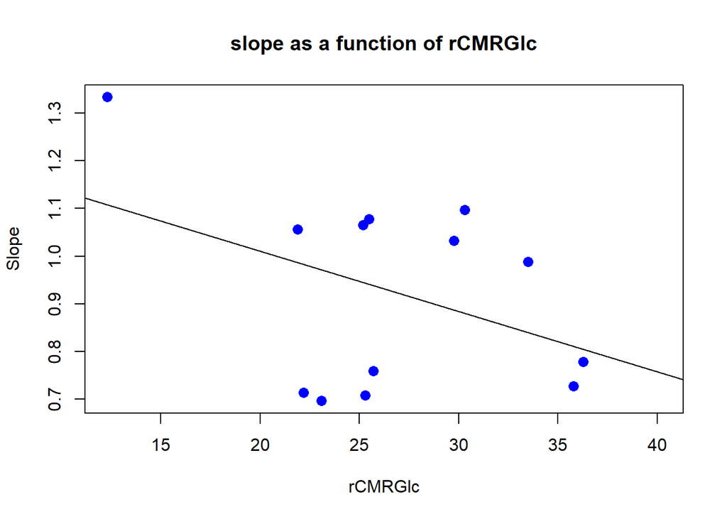

```r
plot(MetaData$rCMRGlc, MetaData$slope,
     pch = 16, cex = 1.3, col = "blue",
     main = "slope as a function of rCMRGlc",
     xlab = "rCMRGlc", ylab = "Slope")
abline(lm.slope)
```

Regression x = rCMRGlc y = lambda

```r
lm.lambda <- lm(lambda ~ rCMRGlc, data = MetaData)
summary(lm.lambda)
```

```
##
## Call:
## lm(formula = lambda ~ rCMRGlc, data = MetaData)
##
## Residuals:
##      Min       1Q   Median       3Q      Max
## -0.81246 -0.08893  0.17016  0.26011  0.31486
##
## Coefficients:
##             Estimate Std. Error t value Pr(>|t|)
## (Intercept)  1.43243    0.46611   3.073   0.0106 *
## rCMRGlc     -0.02793    0.01701  -1.642   0.1288
## ---
## Signif. codes:  0 '***' 0.001 '**' 0.01 '*' 0.05 '.' 0.1 ' ' 1
##
## Residual standard error: 0.3853 on 11 degrees of freedom
##   (32 observations deleted due to missingness)
## Multiple R-squared:  0.1969, Adjusted R-squared:  0.1239
## F-statistic: 2.697 on 1 and 11 DF,  p-value: 0.1288
```

Regression x = rCMRGlc y = OP_Diff

```r
lm.OP_Diff <- lm(OP_Diff ~ rCMRGlc, data = MetaData)
summary(lm.OP_Diff)
```

```
##
## Call:
## lm(formula = OP_Diff ~ rCMRGlc, data = MetaData)
##
## Residuals:
##      Min       1Q   Median       3Q      Max
## -1.00597 -0.23445  0.02012  0.25287  0.75201
##
## Coefficients:
##             Estimate Std. Error t value Pr(>|t|)
## (Intercept) -1.43218    0.58731  -2.439   0.0329 *
## rCMRGlc      0.03590    0.02143   1.675   0.1220
## ---
## Signif. codes:  0 '***' 0.001 '**' 0.01 '*' 0.05 '.' 0.1 ' ' 1
##
## Residual standard error: 0.4855 on 11 degrees of freedom
##   (32 observations deleted due to missingness)
## Multiple R-squared:  0.2033, Adjusted R-squared:  0.1308
## F-statistic: 2.807 on 1 and 11 DF,  p-value: 0.122
```

Regression x = rCMRGlc y = aging_Beta

```r
lm.aging_Beta <- lm(aging_Beta ~ rCMRGlc, data = MetaData)
summary(lm.aging_Beta)
```

```
##
## Call:
## lm(formula = aging_Beta ~ rCMRGlc, data = MetaData)
##
## Residuals:
##      Min       1Q   Median       3Q      Max
## -0.17808 -0.12003 -0.04864  0.12900  0.23223
##
## Coefficients:
##              Estimate Std. Error t value Pr(>|t|)
## (Intercept) -0.197496   0.185729  -1.063   0.3153
## rCMRGlc     -0.012043   0.006314  -1.907   0.0889 .
## ---
## Signif. codes:  0 '***' 0.001 '**' 0.01 '*' 0.05 '.' 0.1 ' ' 1
##
## Residual standard error: 0.1584 on 9 degrees of freedom
##   (34 observations deleted due to missingness)
## Multiple R-squared:  0.2878, Adjusted R-squared:  0.2087
## F-statistic: 3.638 on 1 and 9 DF,  p-value: 0.08885
```

Regression x = rCMRGlc y = aging_change

```r
lm.aging_change <- lm(aging_change ~ rCMRGlc, data = MetaData)
summary(lm.aging_change)
```

```
##
## Call:
## lm(formula = aging_change ~ rCMRGlc, data = MetaData)
##
## Residuals:
##    Min     1Q Median     3Q    Max
## -8.529 -4.287 -2.711  2.224 14.701
##
## Coefficients:
##              Estimate Std. Error t value Pr(>|t|)
## (Intercept) -18.70082    8.80084  -2.125   0.0625 .
## rCMRGlc      -0.09815    0.29920  -0.328   0.7504
## ---
## Signif. codes:  0 '***' 0.001 '**' 0.01 '*' 0.05 '.' 0.1 ' ' 1
##
## Residual standard error: 7.505 on 9 degrees of freedom
##   (34 observations deleted due to missingness)
## Multiple R-squared:  0.01182,    Adjusted R-squared:  -0.09798
## F-statistic: 0.1076 on 1 and 9 DF,  p-value: 0.7504
```

Regression x = rCMRGlc y = development_change

```r
lm.development_change <- lm(development_change ~ rCMRGlc, data = MetaData)
summary(lm.development_change)
```

```
##
## Call:
## lm(formula = development_change ~ rCMRGlc, data = MetaData)
##
## Residuals:
##     Min      1Q  Median      3Q     Max
## -1.4684 -0.7681 -0.1500  0.3981  2.4011
##
## Coefficients:
##             Estimate Std. Error t value Pr(>|t|)
## (Intercept)  3.78869    1.41535   2.677   0.0215 *
## rCMRGlc     -0.12330    0.04806  -2.566   0.0263 *
## ---
## Signif. codes:  0 '***' 0.001 '**' 0.01 '*' 0.05 '.' 0.1 ' ' 1
##
## Residual standard error: 1.23 on 11 degrees of freedom
##   (32 observations deleted due to missingness)
## Multiple R-squared:  0.3744, Adjusted R-squared:  0.3175
## F-statistic: 6.582 on 1 and 11 DF,  p-value: 0.02626
```

SPSS style Type 3 Regression x = rCMRGlc y = development_change

```r
crf.lm.development_change <- lm(development_change ~ rCMRGlc, data = MetaData)
Anova(crf.lm.development_change, type=3)
```

```
## Anova Table (Type III tests)
##
## Response: development_change
##              Sum Sq Df F value  Pr(>F)
## (Intercept) 10.8363  1  7.1656 0.02153 *
## rCMRGlc      9.9535  1  6.5818 0.02626 *
## Residuals   16.6350 11
## ---
## Signif. codes:  0 '***' 0.001 '**' 0.01 '*' 0.05 '.' 0.1 ' ' 1
```

Regression x = rCMRGlc y = Orphan_change

```r
lm.Orphan_change <- lm(Orphan_change ~ rCMRGlc, data = MetaData)
summary(lm.Orphan_change)
```

```
##
## Call:
## lm(formula = Orphan_change ~ rCMRGlc, data = MetaData)
##
## Residuals:
##     Min      1Q  Median      3Q     Max
## -30.872 -18.794 -10.947   1.221  90.813
##
## Coefficients:
##             Estimate Std. Error t value Pr(>|t|)
## (Intercept)  -40.450     71.520  -0.566    0.592
## rCMRGlc        1.783      2.258   0.790    0.460
##
## Residual standard error: 41.58 on 6 degrees of freedom
##   (37 observations deleted due to missingness)
## Multiple R-squared:  0.09412,    Adjusted R-squared:  -0.05686
## F-statistic: 0.6234 on 1 and 6 DF,  p-value: 0.4598
```

SPSS style Type 3 Regression x = rCMRGlc y = Orphan_change

```r
crf.lm.Orphan_change <- lm(Orphan_change ~ rCMRGlc, data = MetaData)
Anova(crf.lm.Orphan_change, type=3)
```

```
## Anova Table (Type III tests)
##
## Response: Orphan_change
##              Sum Sq Df F value Pr(>F)
## (Intercept)   552.9  1  0.3199 0.5922
## rCMRGlc      1077.6  1  0.6234 0.4598
## Residuals   10371.6  6
```

NEW - Michael’s fancy new regressions! Load data above. Regression x = rCMRGlc y = Volume

```r
lm.Volume <- lm(Volume ~ rCMRGlc, data = MetaData)
summary(lm.Volume)
```

```
##
## Call:
## lm(formula = Volume ~ rCMRGlc, data = MetaData)
##
## Residuals:
##       1       2       3       4       5      19
## 138.318  -2.814 -43.248  -9.359 -63.255 -19.641
##
## Coefficients:
##             Estimate Std. Error t value Pr(>|t|)
## (Intercept)  -90.559    219.457  -0.413    0.701
## rCMRGlc        5.088      6.743   0.755    0.493
##
## Residual standard error: 79.82 on 4 degrees of freedom
##   (39 observations deleted due to missingness)
## Multiple R-squared:  0.1246, Adjusted R-squared:  -0.09425
## F-statistic: 0.5694 on 1 and 4 DF,  p-value: 0.4925
```

SPSS style Type 3 Regression x = rCMRGlc y = Volume

```r
crf.lm.Volume <- lm(Volume ~ rCMRGlc, data = MetaData)
Anova(crf.lm.Volume, type=3)
```

```
## Anova Table (Type III tests)
##
## Response: Volume
##              Sum Sq Df F value Pr(>F)
## (Intercept)  1084.9  1  0.1703 0.7010
## rCMRGlc      3627.5  1  0.5694 0.4925
## Residuals   25484.7  4
```

Regression x = rCMRGlc y = VolumeSD

```r
lm.VolumeSD <- lm(VolumeSD ~ rCMRGlc, data = MetaData)
summary(lm.VolumeSD)
```

```
##
## Call:
## lm(formula = VolumeSD ~ rCMRGlc, data = MetaData)
##
## Residuals:
##       1       2       3       4       5      19
## 21.4410  0.5625 -8.5746 -0.7061 -9.3512 -3.3716
##
## Coefficients:
##             Estimate Std. Error t value Pr(>|t|)
## (Intercept)  -18.906     34.583  -0.547    0.614
## rCMRGlc        1.009      1.063   0.949    0.396
##
## Residual standard error: 12.58 on 4 degrees of freedom
##   (39 observations deleted due to missingness)
## Multiple R-squared:  0.1838, Adjusted R-squared:  -0.02022
## F-statistic: 0.9009 on 1 and 4 DF,  p-value: 0.3963
```

SPSS style Type 3 Regression x = rCMRGlc y = VolumeSD

```r
crf.lm.VolumeSD <- lm(VolumeSD ~ rCMRGlc, data = MetaData)
Anova(crf.lm.VolumeSD, type=3)
```

```
## Anova Table (Type III tests)
##
## Response: VolumeSD
##             Sum Sq Df F value Pr(>F)
## (Intercept)  47.29  1  0.2989 0.6137
## rCMRGlc     142.54  1  0.9009 0.3963
## Residuals   632.87  4
```

Regression x = rCMRGlc y = Neuron_N

```r
lm.Neuron_N <- lm(Neuron_N ~ rCMRGlc, data = MetaData)
summary(lm.Neuron_N)
```

```
##
## Call:
## lm(formula = Neuron_N ~ rCMRGlc, data = MetaData)
##
## Residuals:
##          1          2          3          4          5         19
##  1.126e+10 -1.250e+09 -3.592e+09 -9.951e+08 -3.954e+09 -1.471e+09
##
## Coefficients:
##               Estimate Std. Error t value Pr(>|t|)
## (Intercept) -8.433e+09  1.739e+10  -0.485    0.653
## rCMRGlc      4.461e+08  5.344e+08   0.835    0.451
##
## Residual standard error: 6.326e+09 on 4 degrees of freedom
##   (39 observations deleted due to missingness)
## Multiple R-squared:  0.1484, Adjusted R-squared:  -0.06456
## F-statistic: 0.6968 on 1 and 4 DF,  p-value: 0.4508
```

SPSS style Type 3 Regression x = rCMRGlc y = Neuron_N

```r
crf.lm.Neuron_N <- lm(Neuron_N ~ rCMRGlc, data = MetaData)
Anova(crf.lm.Neuron_N, type=3)
```

```
## Anova Table (Type III tests)
##
## Response: Neuron_N
##                 Sum Sq Df F value Pr(>F)
## (Intercept) 9.4078e+18  1  0.2351 0.6531
## rCMRGlc     2.7885e+19  1  0.6968 0.4508
## Residuals   1.6008e+20  4
```

Regression x = rCMRGlc y = NeuronSD

```r
lm.NeuronSD <- lm(NeuronSD ~ rCMRGlc, data = MetaData)
summary(lm.NeuronSD)
```

```
##
## Call:
## lm(formula = NeuronSD ~ rCMRGlc, data = MetaData)
##
## Residuals:
##          1          2          3          4          5         19
##  959136463 -765324045 -283320434  430959544  -39434071 -302017458
##
## Coefficients:
##               Estimate Std. Error t value Pr(>|t|)
## (Intercept) -1.096e+09  1.877e+09  -0.584    0.591
## rCMRGlc      6.296e+07  5.768e+07   1.092    0.336
##
## Residual standard error: 682700000 on 4 degrees of freedom
##   (39 observations deleted due to missingness)
## Multiple R-squared:  0.2295, Adjusted R-squared:  0.03688
## F-statistic: 1.191 on 1 and 4 DF,  p-value: 0.3364
```

SPSS style Type 3 Regression x = rCMRGlc y = NeuronSD

```r
crf.lm.NeuronSD <- lm(NeuronSD ~ rCMRGlc, data = MetaData)
Anova(crf.lm.NeuronSD, type=3)
```

```
## Anova Table (Type III tests)
##
## Response: NeuronSD
##                 Sum Sq Df F value Pr(>F)
## (Intercept) 1.5880e+17  1  0.3407 0.5908
## rCMRGlc     5.5534e+17  1  1.1914 0.3364
## Residuals   1.8644e+18  4
```

Regression x = rCMRGlc y = NeurDensity

```r
lm.NeurDensity <- lm(NeurDensity ~ rCMRGlc, data = MetaData)
summary(lm.NeurDensity)
```

```
##
## Call:
## lm(formula = NeurDensity ~ rCMRGlc, data = MetaData)
##
## Residuals:
##         1         2         3         4         5        12        19
##  10479255 -12780167  -4863128  24843134  39984017 -62855198   5192087
##
## Coefficients:
##               Estimate Std. Error t value Pr(>|t|)
## (Intercept) -154796217   98948667  -1.564   0.1785
## rCMRGlc        6739324    3043700   2.214   0.0777 .
## ---
## Signif. codes:  0 '***' 0.001 '**' 0.01 '*' 0.05 '.' 0.1 ' ' 1
##
## Residual standard error: 36030000 on 5 degrees of freedom
##   (38 observations deleted due to missingness)
## Multiple R-squared:  0.4951, Adjusted R-squared:  0.3941
## F-statistic: 4.903 on 1 and 5 DF,  p-value: 0.07769
```

SPSS style Type 3 Regression x = rCMRGlc y = NeurDensity

```r
crf.lm.NeurDensity <- lm(NeurDensity ~ rCMRGlc, data = MetaData)
Anova(crf.lm.NeurDensity, type=3)
```

```
## Anova Table (Type III tests)
##
## Response: NeurDensity
##                 Sum Sq Df F value  Pr(>F)
## (Intercept) 3.1769e+15  1  2.4474 0.17849
## rCMRGlc     6.3640e+15  1  4.9026 0.07769 .
## Residuals   6.4904e+15  5
## ---
## Signif. codes:  0 '***' 0.001 '**' 0.01 '*' 0.05 '.' 0.1 ' ' 1
```

Regression x = rCMRGlc y = Glia_N

```r
lm.Glia_N <- lm(Glia_N ~ rCMRGlc, data = MetaData)
summary(lm.Glia_N)
```

```
##
## Call:
## lm(formula = Glia_N ~ rCMRGlc, data = MetaData)
##
## Residuals:
##          1          2          3          4          5         19
##  1.215e+10 -4.526e+08 -3.967e+09 -7.898e+08 -5.211e+09 -1.731e+09
##
## Coefficients:
##               Estimate Std. Error t value Pr(>|t|)
## (Intercept) -8.614e+09  1.917e+10  -0.449    0.676
## rCMRGlc      4.660e+08  5.889e+08   0.791    0.473
##
## Residual standard error: 6.971e+09 on 4 degrees of freedom
##   (39 observations deleted due to missingness)
## Multiple R-squared:  0.1353, Adjusted R-squared:  -0.08085
## F-statistic: 0.626 on 1 and 4 DF,  p-value: 0.4731
```

SPSS style Type 3 Regression x = rCMRGlc y = Glia_N

```r
crf.lm.Glia_N <- lm(Glia_N ~ rCMRGlc, data = MetaData)
Anova(crf.lm.Glia_N, type=3)
```

```
## Anova Table (Type III tests)
##
## Response: Glia_N
##                 Sum Sq Df F value Pr(>F)
## (Intercept) 9.8149e+18  1   0.202 0.6764
## rCMRGlc     3.0420e+19  1   0.626 0.4731
## Residuals   1.9437e+20  4
```

Regression x = rCMRGlc y = GliaSD

```r
lm.GliaSD <- lm(GliaSD ~ rCMRGlc, data = MetaData)
summary(lm.GliaSD)
```

```
##
## Call:
## lm(formula = GliaSD ~ rCMRGlc, data = MetaData)
##
## Residuals:
##          1          2          3          4          5         19
## 1604600170   31444084 -826577948 -128828012 -458321090 -222317204
##
## Coefficients:
##               Estimate Std. Error t value Pr(>|t|)
## (Intercept) -1.706e+09  2.585e+09  -0.660    0.545
## rCMRGlc      8.685e+07  7.942e+07   1.094    0.336
##
## Residual standard error: 940100000 on 4 degrees of freedom
##   (39 observations deleted due to missingness)
## Multiple R-squared:  0.2302, Adjusted R-squared:  0.03769
## F-statistic: 1.196 on 1 and 4 DF,  p-value: 0.3356
```

SPSS style Type 3 Regression x = rCMRGlc y = GliaSD

```r
crf.lm.GliaSD <- lm(GliaSD ~ rCMRGlc, data = MetaData)
Anova(crf.lm.GliaSD, type=3)
```

```
## Anova Table (Type III tests)
##
## Response: GliaSD
##                 Sum Sq Df F value Pr(>F)
## (Intercept) 3.8490e+17  1  0.4355 0.5454
## rCMRGlc     1.0568e+18  1  1.1958 0.3356
## Residuals   3.5350e+18  4
```

Regression x = rCMRGlc y = GliaDensity

```r
lm.GliaDensity <- lm(GliaDensity ~ rCMRGlc, data = MetaData)
summary(lm.GliaDensity)
```

```
##
## Call:
## lm(formula = GliaDensity ~ rCMRGlc, data = MetaData)
##
## Residuals:
##         1         2         3         4         5        12        19
##  15687154   1987251  -2018005  34184989  13957224 -64297685    499072
##
## Coefficients:
##               Estimate Std. Error t value Pr(>|t|)
## (Intercept) -142936794   93149661  -1.534   0.1855
## rCMRGlc        6417747    2865320   2.240   0.0752 .
## ---
## Signif. codes:  0 '***' 0.001 '**' 0.01 '*' 0.05 '.' 0.1 ' ' 1
##
## Residual standard error: 33920000 on 5 degrees of freedom
##   (38 observations deleted due to missingness)
## Multiple R-squared:  0.5008, Adjusted R-squared:  0.401
## F-statistic: 5.017 on 1 and 5 DF,  p-value: 0.07523
```

SPSS style Type 3 Regression x = rCMRGlc y = GliaDensity

```r
crf.lm.GliaDensity <- lm(GliaDensity ~ rCMRGlc, data = MetaData)
Anova(crf.lm.GliaDensity, type=3)
```

```
## Anova Table (Type III tests)
##
## Response: GliaDensity
##                 Sum Sq Df F value  Pr(>F)
## (Intercept) 2.7088e+15  1  2.3546 0.18550
## rCMRGlc     5.7712e+15  1  5.0167 0.07523 .
## Residuals   5.7520e+15  5
## ---
## Signif. codes:  0 '***' 0.001 '**' 0.01 '*' 0.05 '.' 0.1 ' ' 1
```

Regression x = rCMRGlc y = Astro_N

```r
lm.Astro_N <- lm(Astro_N ~ rCMRGlc, data = MetaData)
summary(lm.Astro_N)
```

```
##
## Call:
## lm(formula = Astro_N ~ rCMRGlc, data = MetaData)
##
## Residuals:
##          1          2          3          4          5         19
##  3.278e+09  1.799e+08 -1.090e+09 -3.447e+08 -1.597e+09 -4.267e+08
##
## Coefficients:
##               Estimate Std. Error t value Pr(>|t|)
## (Intercept) -2.702e+09  5.291e+09  -0.511    0.636
## rCMRGlc      1.409e+08  1.626e+08   0.867    0.435
##
## Residual standard error: 1.925e+09 on 4 degrees of freedom
##   (39 observations deleted due to missingness)
## Multiple R-squared:  0.1581, Adjusted R-squared:  -0.05234
## F-statistic: 0.7513 on 1 and 4 DF,  p-value: 0.435
```

SPSS style Type 3 Regression x = rCMRGlc y = Astro_N

```r
crf.lm.Astro_N <- lm(Astro_N ~ rCMRGlc, data = MetaData)
Anova(crf.lm.Astro_N, type=3)
```

```
## Anova Table (Type III tests)
##
## Response: Astro_N
##                 Sum Sq Df F value Pr(>F)
## (Intercept) 9.6583e+17  1  0.2608 0.6365
## rCMRGlc     2.7828e+18  1  0.7513 0.4350
## Residuals   1.4816e+19  4
```

Regression x = rCMRGlc y = AstroSD

```r
lm.AstroSD <- lm(AstroSD ~ rCMRGlc, data = MetaData)
summary(lm.AstroSD)
```

```
##
## Call:
## lm(formula = AstroSD ~ rCMRGlc, data = MetaData)
##
## Residuals:
##          1          2          3          4          5         19
##  530283304  437409901 -316388491 -244870651 -396100085  -10333978
##
## Coefficients:
##               Estimate Std. Error t value Pr(>|t|)
## (Intercept) -937342988 1221552001  -0.767    0.486
## rCMRGlc       42688240   37535285   1.137    0.319
##
## Residual standard error: 444300000 on 4 degrees of freedom
##   (39 observations deleted due to missingness)
## Multiple R-squared:  0.2443, Adjusted R-squared:  0.05543
## F-statistic: 1.293 on 1 and 4 DF,  p-value: 0.3189
```

SPSS style Type 3 Regression x = rCMRGlc y = AstroSD

```r
crf.lm.AstroSD <- lm(AstroSD ~ rCMRGlc, data = MetaData)
Anova(crf.lm.AstroSD, type=3)
```

```
## Anova Table (Type III tests)
##
## Response: AstroSD
##                 Sum Sq Df F value Pr(>F)
## (Intercept) 1.1623e+17  1  0.5888 0.4857
## rCMRGlc     2.5532e+17  1  1.2934 0.3189
## Residuals   7.8959e+17  4
```

Regression x = rCMRGlc y = AstroDensity

```r
lm.AstroDensity <- lm(AstroDensity ~ rCMRGlc, data = MetaData)
summary(lm.AstroDensity)
```

```
##
## Call:
## lm(formula = AstroDensity ~ rCMRGlc, data = MetaData)
##
## Residuals:
##        1        2        3        4        5       19
##   452634  1130137 -2351395  4634941 -1941955 -1924361
##
## Coefficients:
##              Estimate Std. Error t value Pr(>|t|)
## (Intercept) -41077616    8244598  -4.982  0.00758 **
## rCMRGlc       1937320     253336   7.647  0.00157 **
## ---
## Signif. codes:  0 '***' 0.001 '**' 0.01 '*' 0.05 '.' 0.1 ' ' 1
##
## Residual standard error: 2999000 on 4 degrees of freedom
##   (39 observations deleted due to missingness)
## Multiple R-squared:  0.936,  Adjusted R-squared:   0.92
## F-statistic: 58.48 on 1 and 4 DF,  p-value: 0.001571
```

SPSS style Type 3 Regression x = rCMRGlc y = AstroDensity

```r
crf.lm.AstroDensity <- lm(AstroDensity ~ rCMRGlc, data = MetaData)
Anova(crf.lm.AstroDensity, type=3)
```

```
## Anova Table (Type III tests)
##
## Response: AstroDensity
##                 Sum Sq Df F value   Pr(>F)
## (Intercept) 2.2322e+14  1  24.824 0.007585 **
## rCMRGlc     5.2586e+14  1  58.480 0.001571 **
## Residuals   3.5968e+13  4
## ---
## Signif. codes:  0 '***' 0.001 '**' 0.01 '*' 0.05 '.' 0.1 ' ' 1
```

Regression x = rCMRGlc y = Oligo_N

```r
lm.Oligo_N <- lm(Oligo_N ~ rCMRGlc, data = MetaData)
summary(lm.Oligo_N)
```

```
##
## Call:
## lm(formula = Oligo_N ~ rCMRGlc, data = MetaData)
##
## Residuals:
##          1          2          3          4          5         19
##  6.655e+09 -3.689e+08 -2.250e+09 -3.002e+08 -2.741e+09 -9.949e+08
##
## Coefficients:
##               Estimate Std. Error t value Pr(>|t|)
## (Intercept) -4.558e+09  1.048e+10  -0.435    0.686
## rCMRGlc      2.501e+08  3.219e+08   0.777    0.481
##
## Residual standard error: 3.811e+09 on 4 degrees of freedom
##   (39 observations deleted due to missingness)
## Multiple R-squared:  0.1311, Adjusted R-squared:  -0.08607
## F-statistic: 0.6037 on 1 and 4 DF,  p-value: 0.4805
```

SPSS style Type 3 Regression x = rCMRGlc y = Oligo_N

```r
crf.lm.Oligo_N <- lm(Oligo_N ~ rCMRGlc, data = MetaData)
Anova(crf.lm.Oligo_N, type=3)
```

```
## Anova Table (Type III tests)
##
## Response: Oligo_N
##                 Sum Sq Df F value Pr(>F)
## (Intercept) 2.7486e+18  1  0.1893 0.6860
## rCMRGlc     8.7669e+18  1  0.6037 0.4805
## Residuals   5.8083e+19  4
```

Regression x = rCMRGlc y = OligoSD

```r
lm.OligoSD <- lm(OligoSD ~ rCMRGlc, data = MetaData)
summary(lm.OligoSD)
```

```
##
## Call:
## lm(formula = OligoSD ~ rCMRGlc, data = MetaData)
##
## Residuals:
##          1          2          3          4          5         19
## 1354233029   34843319 -661495016   54185328 -530344612 -251422049
##
## Coefficients:
##               Estimate Std. Error t value Pr(>|t|)
## (Intercept) -1.109e+09  2.225e+09  -0.498    0.644
## rCMRGlc      6.126e+07  6.838e+07   0.896    0.421
##
## Residual standard error: 809300000 on 4 degrees of freedom
##   (39 observations deleted due to missingness)
## Multiple R-squared:  0.1671, Adjusted R-squared:  -0.04106
## F-statistic: 0.8028 on 1 and 4 DF,  p-value: 0.4209
```

SPSS style Type 3 Regression x = rCMRGlc y = OligoSD

```r
crf.lm.OligoSD <- lm(OligoSD ~ rCMRGlc, data = MetaData)
Anova(crf.lm.OligoSD, type=3)
```

```
## Anova Table (Type III tests)
##
## Response: OligoSD
##                 Sum Sq Df F value Pr(>F)
## (Intercept) 1.6259e+17  1  0.2482 0.6445
## rCMRGlc     5.2585e+17  1  0.8028 0.4209
## Residuals   2.6202e+18  4
```

Regression x = rCMRGlc y = OligoDensity

```r
lm.OligoDensity <- lm(OligoDensity ~ rCMRGlc, data = MetaData)
summary(lm.OligoDensity)
```

```
##
## Call:
## lm(formula = OligoDensity ~ rCMRGlc, data = MetaData)
##
## Residuals:
##        1        2        3        4        5       19
##  2352887 -6717234 -9320772 14997289  4683319 -5995489
##
## Coefficients:
##              Estimate Std. Error t value Pr(>|t|)
## (Intercept) -71864485   28184255  -2.550   0.0633 .
## rCMRGlc       3508139     866033   4.051   0.0155 *
## ---
## Signif. codes:  0 '***' 0.001 '**' 0.01 '*' 0.05 '.' 0.1 ' ' 1
##
## Residual standard error: 10250000 on 4 degrees of freedom
##   (39 observations deleted due to missingness)
## Multiple R-squared:  0.804,  Adjusted R-squared:  0.755
## F-statistic: 16.41 on 1 and 4 DF,  p-value: 0.01547
```

SPSS style Type 3 Regression x = rCMRGlc y = OligoDensity

```r
crf.lm.OligoDensity <- lm(OligoDensity ~ rCMRGlc, data = MetaData)
Anova(crf.lm.OligoDensity, type=3)
```

```
## Anova Table (Type III tests)
##
## Response: OligoDensity
##                 Sum Sq Df F value  Pr(>F)
## (Intercept) 6.8320e+14  1  6.5015 0.06332 .
## rCMRGlc     1.7243e+15  1 16.4091 0.01547 *
## Residuals   4.2033e+14  4
## ---
## Signif. codes:  0 '***' 0.001 '**' 0.01 '*' 0.05 '.' 0.1 ' ' 1
```

Regression x = rCMRGlc y = Microglia_N

```r
lm.Microglia_N <- lm(Microglia_N ~ rCMRGlc, data = MetaData)
summary(lm.Microglia_N)
```

```
##
## Call:
## lm(formula = Microglia_N ~ rCMRGlc, data = MetaData)
##
## Residuals:
##          1          2          3          4          5         19
## 1571708673   37814615 -526545726 -136570122 -732435704 -213971736
##
## Coefficients:
##               Estimate Std. Error t value Pr(>|t|)
## (Intercept) -1.147e+09  2.516e+09  -0.456    0.672
## rCMRGlc      6.133e+07  7.731e+07   0.793    0.472
##
## Residual standard error: 915100000 on 4 degrees of freedom
##   (39 observations deleted due to missingness)
## Multiple R-squared:  0.1359, Adjusted R-squared:  -0.0801
## F-statistic: 0.6292 on 1 and 4 DF,  p-value: 0.472
```

SPSS style Type 3 Regression x = rCMRGlc y = Microglia_N

```r
crf.lm.Microglia_N <- lm(Microglia_N ~ rCMRGlc, data = MetaData)
Anova(crf.lm.Microglia_N, type=3)
```

```
## Anova Table (Type III tests)
##
## Response: Microglia_N
##                 Sum Sq Df F value Pr(>F)
## (Intercept) 1.7418e+17  1  0.2080  0.672
## rCMRGlc     5.2694e+17  1  0.6292  0.472
## Residuals   3.3498e+18  4
```

Regression x = rCMRGlc y = MicroSD

```r
lm.MicroSD <- lm(MicroSD ~ rCMRGlc, data = MetaData)
summary(lm.MicroSD)
```

```
##
## Call:
## lm(formula = MicroSD ~ rCMRGlc, data = MetaData)
##
## Residuals:
##          1          2          3          4          5         19
##  376400064  -22783843 -106737500  -24982917 -168813542  -53082262
##
## Coefficients:
##               Estimate Std. Error t value Pr(>|t|)
## (Intercept) -374363898  592128599  -0.632    0.562
## rCMRGlc       19254392   18194654   1.058    0.350
##
## Residual standard error: 215400000 on 4 degrees of freedom
##   (39 observations deleted due to missingness)
## Multiple R-squared:  0.2187, Adjusted R-squared:  0.02341
## F-statistic:  1.12 on 1 and 4 DF,  p-value: 0.3496
```

SPSS style Type 3 Regression x = rCMRGlc y = MicroSD

```r
crf.lm.MicroSD <- lm(MicroSD ~ rCMRGlc, data = MetaData)
Anova(crf.lm.MicroSD, type=3)
```

```
## Anova Table (Type III tests)
##
## Response: MicroSD
##                 Sum Sq Df F value Pr(>F)
## (Intercept) 1.8540e+16  1  0.3997 0.5616
## rCMRGlc     5.1943e+16  1  1.1199 0.3496
## Residuals   1.8553e+17  4
```

Regression x = rCMRGlc y = MicroDensity

```r
lm.MicroDensity <- lm(MicroDensity ~ rCMRGlc, data = MetaData)
summary(lm.MicroDensity)
```

```
##
## Call:
## lm(formula = MicroDensity ~ rCMRGlc, data = MetaData)
##
## Residuals:
##        1        2        3        4        5       19
##   928796   334581 -1523977  2629951 -1175067 -1194284
##
## Coefficients:
##              Estimate Std. Error t value Pr(>|t|)
## (Intercept) -16934372    4960552  -3.414  0.02693 *
## rCMRGlc        816850     152426   5.359  0.00585 **
## ---
## Signif. codes:  0 '***' 0.001 '**' 0.01 '*' 0.05 '.' 0.1 ' ' 1
##
## Residual standard error: 1804000 on 4 degrees of freedom
##   (39 observations deleted due to missingness)
## Multiple R-squared:  0.8777, Adjusted R-squared:  0.8472
## F-statistic: 28.72 on 1 and 4 DF,  p-value: 0.00585
```

SPSS style Type 3 Regression x = rCMRGlc y = MicroDensity

```r
crf.lm.MicroDensity <- lm(MicroDensity ~ rCMRGlc, data = MetaData)
Anova(crf.lm.MicroDensity, type=3)
```

```
## Anova Table (Type III tests)
##
## Response: MicroDensity
##                 Sum Sq Df F value  Pr(>F)
## (Intercept) 3.7937e+13  1  11.654 0.02693 *
## rCMRGlc     9.3486e+13  1  28.719 0.00585 **
## Residuals   1.3021e+13  4
## ---
## Signif. codes:  0 '***' 0.001 '**' 0.01 '*' 0.05 '.' 0.1 ' ' 1
```

Regression x = rCMRGlc y = GliaNeurDensityRatio

```r
lm.GliaNeurDensityRatio <- lm(GliaNeurDensityRatio ~ rCMRGlc, data = MetaData)
summary(lm.GliaNeurDensityRatio)
```

```
##
## Call:
## lm(formula = GliaNeurDensityRatio ~ rCMRGlc, data = MetaData)
##
## Residuals:
##        1        2        3        4        5       12       19
## -0.26527  0.27235  0.20279 -0.85795 -0.04021  0.42966  0.25862
##
## Coefficients:
##             Estimate Std. Error t value Pr(>|t|)
## (Intercept)  8.74525    1.33127   6.569  0.00123 **
## rCMRGlc     -0.22089    0.04095  -5.394  0.00296 **
## ---
## Signif. codes:  0 '***' 0.001 '**' 0.01 '*' 0.05 '.' 0.1 ' ' 1
##
## Residual standard error: 0.4847 on 5 degrees of freedom
##   (38 observations deleted due to missingness)
## Multiple R-squared:  0.8534, Adjusted R-squared:  0.824
## F-statistic:  29.1 on 1 and 5 DF,  p-value: 0.002956
```

SPSS style Type 3 Regression x = rCMRGlc y = GliaNeurDensityRatio

```r
crf.lm.GliaNeurDensityRatio <- lm(GliaNeurDensityRatio ~ rCMRGlc, data = MetaData)
Anova(crf.lm.GliaNeurDensityRatio, type=3)
```

```
## Anova Table (Type III tests)
##
## Response: GliaNeurDensityRatio
##              Sum Sq Df F value   Pr(>F)
## (Intercept) 10.1398  1  43.153 0.001226 **
## rCMRGlc      6.8371  1  29.098 0.002956 **
## Residuals    1.1749  5
## ---
## Signif. codes:  0 '***' 0.001 '**' 0.01 '*' 0.05 '.' 0.1 ' ' 1
```

## MICHAEL OPTIMIZED LLM LOOP CODE

```r
dep_vars <- c(
  "Volume", "VolumeSD", "Neuron_N", "NeuronSD", "NeurDensity",
  "Glia_N", "GliaSD", "GliaDensity",
  "Astro_N", "AstroSD", "AstroDensity",
  "Oligo_N", "OligoSD", "OligoDensity",
  "Microglia_N", "MicroSD", "MicroDensity",
  "GliaNeurDensityRatio"
)
```

```r
# Prepare lists to store results
regression_results <- list()
anova_results <- list()

# Prepare a summary table
summary_table <- data.frame(
  Dependent = character(),
  Estimate = numeric(),
  StdError = numeric(),
  tValue = numeric(),
  pValue = numeric(),
  stringsAsFactors = FALSE
)

# Loop through each dependent variable
for (dv in dep_vars) {
  formula <- as.formula(paste(dv, "~ rCMRGlc"))
  model <- lm(formula, data = MetaData)
  regression_results[[dv]] <- summary(model)
  anova_results[[dv]] <- Anova(model, type = 3)

  # Extract coefficient info for summary table
  coef_info <- summary(model)$coefficients["rCMRGlc", ]
  summary_table <- rbind(summary_table, data.frame(
    Dependent = dv,
    Estimate = coef_info["Estimate"],
    StdError = coef_info["Std. Error"],
    tValue = coef_info["t value"],
    pValue = coef_info["Pr(>|t|)"]
  ))
}
```

Display all results in console

```r
for (dv in dep_vars) {
  cat("\n--- Regression for", dv, "~ rCMRGlc ---\n")
  print(regression_results[[dv]])
  cat("\n--- Type III ANOVA for", dv, "~ rCMRGlc ---\n")
  print(anova_results[[dv]])
}
```

```
##
## --- Regression for Volume ~ rCMRGlc ---
##
## Call:
## lm(formula = formula, data = MetaData)
##
## Residuals:
##       1       2       3       4       5      19
## 138.318  -2.814 -43.248  -9.359 -63.255 -19.641
##
## Coefficients:
##             Estimate Std. Error t value Pr(>|t|)
## (Intercept)  -90.559    219.457  -0.413    0.701
## rCMRGlc        5.088      6.743   0.755    0.493
##
## Residual standard error: 79.82 on 4 degrees of freedom
##   (39 observations deleted due to missingness)
## Multiple R-squared:  0.1246, Adjusted R-squared:  -0.09425
## F-statistic: 0.5694 on 1 and 4 DF,  p-value: 0.4925
##
##
## --- Type III ANOVA for Volume ~ rCMRGlc ---
## Anova Table (Type III tests)
##
## Response: Volume
##              Sum Sq Df F value Pr(>F)
## (Intercept)  1084.9  1  0.1703 0.7010
## rCMRGlc      3627.5  1  0.5694 0.4925
## Residuals   25484.7  4
##
## --- Regression for VolumeSD ~ rCMRGlc ---
##
## Call:
## lm(formula = formula, data = MetaData)
##
## Residuals:
##       1       2       3       4       5      19
## 21.4410  0.5625 -8.5746 -0.7061 -9.3512 -3.3716
##
## Coefficients:
```

[output cut: 491 more lines]

```
##   (38 observations deleted due to missingness)
## Multiple R-squared:  0.8534, Adjusted R-squared:  0.824
## F-statistic:  29.1 on 1 and 5 DF,  p-value: 0.002956
##
##
## --- Type III ANOVA for GliaNeurDensityRatio ~ rCMRGlc ---
## Anova Table (Type III tests)
##
## Response: GliaNeurDensityRatio
##              Sum Sq Df F value   Pr(>F)
## (Intercept) 10.1398  1  43.153 0.001226 **
## rCMRGlc      6.8371  1  29.098 0.002956 **
## Residuals    1.1749  5
## ---
## Signif. codes:  0 '***' 0.001 '**' 0.01 '*' 0.05 '.' 0.1 ' ' 1
```

Save summary table

```r
write.csv(summary_table, "regression_summary_table.csv", row.names = FALSE)
print(summary_table)
```

```
##                       Dependent      Estimate     StdError     tValue      pValue
## Estimate                 Volume  5.088268e+00 6.743376e+00  0.7545579 0.492503848
## Estimate1              VolumeSD  1.008643e+00 1.062661e+00  0.9491674 0.396282899
## Estimate2              Neuron_N  4.461199e+08 5.344450e+08  0.8347349 0.450820768
## Estimate3              NeuronSD  6.295734e+07 5.767811e+07  1.0915292 0.336379615
## Estimate4           NeurDensity  6.739324e+06 3.043700e+06  2.2141880 0.077694039
## Estimate5                Glia_N  4.659555e+08 5.889203e+08  0.7912030 0.473096885
## Estimate6                GliaSD  8.685001e+07 7.942099e+07  1.0935398 0.335594624
## Estimate7           GliaDensity  6.417747e+06 2.865320e+06  2.2398011 0.075233422
## Estimate8               Astro_N  1.409325e+08 1.625933e+08  0.8667792 0.434963187
## Estimate9               AstroSD  4.268824e+07 3.753528e+07  1.1372830 0.318923807
## Estimate10         AstroDensity  1.937320e+06 2.533362e+05  7.6472290 0.001571011
## Estimate11              Oligo_N  2.501445e+08 3.219311e+08  0.7770125 0.480541129
## Estimate12              OligoSD  6.126337e+07 6.837561e+07  0.8959828 0.420909163
## Estimate13         OligoDensity  3.508139e+06 8.660328e+05  4.0508155 0.015465318
## Estimate14          Microglia_N  6.132669e+07 7.731263e+07  0.7932300 0.472040902
## Estimate15              MicroSD  1.925439e+07 1.819465e+07  1.0582445 0.349617384
## Estimate16         MicroDensity  8.168498e+05 1.524255e+05  5.3590087 0.005850204
## Estimate17 GliaNeurDensityRatio -2.208949e-01 4.095024e-02 -5.3942288 0.002956045
```

Save full results to text file

```r
sink("regression_full_results.txt")
for (dv in dep_vars) {
  cat("\n--- Regression for", dv, "~ rCMRGlc ---\n")
  print(regression_results[[dv]])
  cat("\n--- Type III ANOVA for", dv, "~ rCMRGlc ---\n")
  print(anova_results[[dv]])
}
sink()
```

# NEW: Individual Cell Type Plots (Nandita-Style)

## Create Individual Regression Plots for Each Cell Type

```
##
## === Neuron Count vs rCMRGlc ===
## Pearson r = 0.385
## p-value = 0.4508
## 95% CI: [-0.620, 0.912]
## R² = 0.148
## Regression: Neuron Count = -8.43e+09 + 4.46e+08 * rCMRGlc
```

```
## Saved: CellType_Neurons_vs_rCMRGlc.png
##
## === Glia Count vs rCMRGlc ===
## Pearson r = 0.368
## p-value = 0.4731
## 95% CI: [-0.633, 0.908]
## R² = 0.135
## Regression: Glia Count = -8.61e+09 + 4.66e+08 * rCMRGlc
```

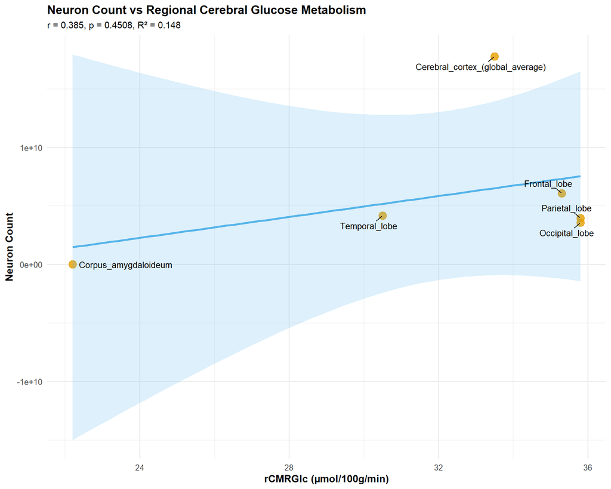

```
## Saved: CellType_Glia_vs_rCMRGlc.png
##
## === Astrocyte Count vs rCMRGlc ===
## Pearson r = 0.398
## p-value = 0.4350
## 95% CI: [-0.611, 0.914]
## R² = 0.158
## Regression: Astrocyte Count = -2.70e+09 + 1.41e+08 * rCMRGlc
```

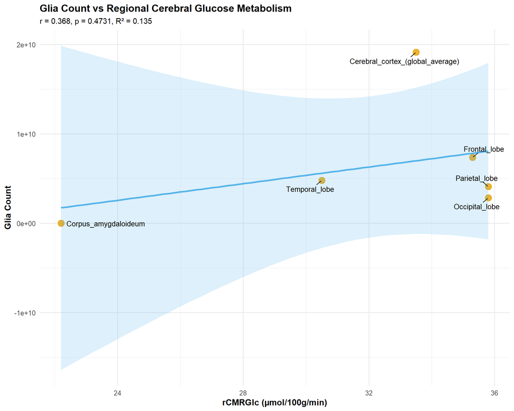

```
## Saved: CellType_Astrocytes_vs_rCMRGlc.png
##
## === Oligodendrocyte Count vs rCMRGlc ===
## Pearson r = 0.362
## p-value = 0.4805
## 95% CI: [-0.636, 0.907]
## R² = 0.131
## Regression: Oligodendrocyte Count = -4.56e+09 + 2.50e+08 * rCMRGlc
```

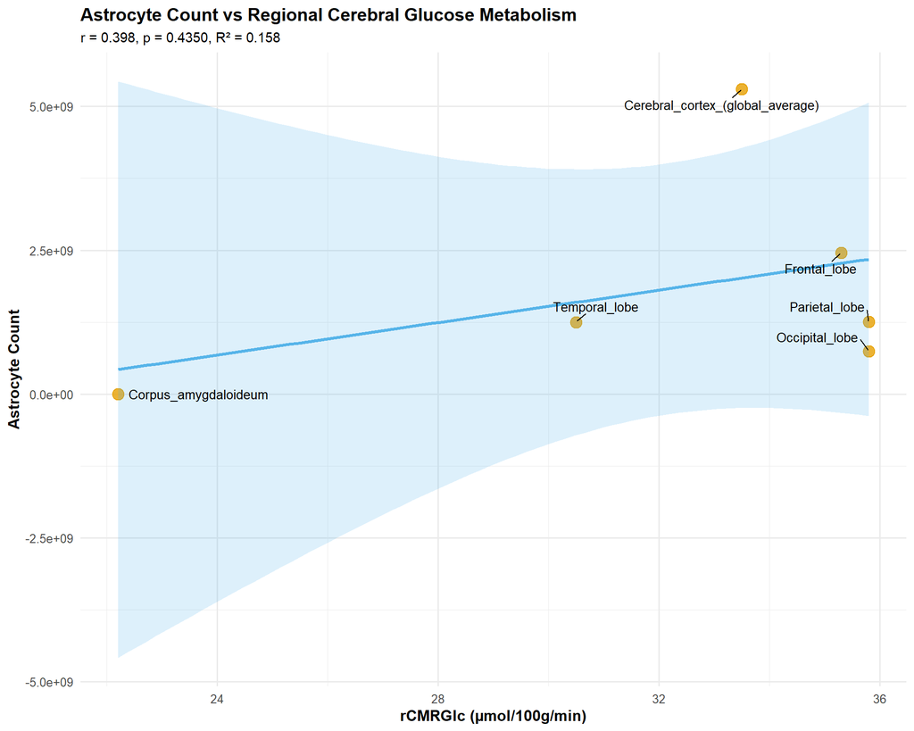

```
## Saved: CellType_Oligodendrocytes_vs_rCMRGlc.png
##
## === Microglia Count vs rCMRGlc ===
## Pearson r = 0.369
## p-value = 0.4720
## 95% CI: [-0.632, 0.908]
## R² = 0.136
## Regression: Microglia Count = -1.15e+09 + 6.13e+07 * rCMRGlc
```

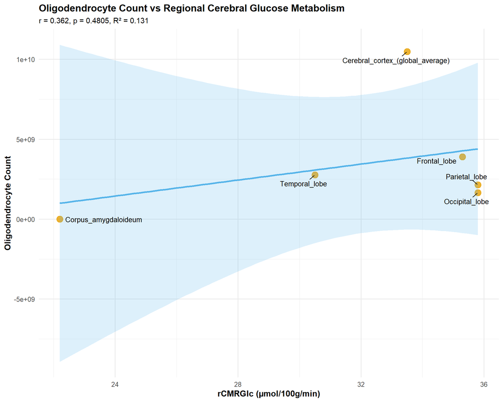

```
## Saved: CellType_Microglia_vs_rCMRGlc.png
##
## === Neuron Density vs rCMRGlc ===
## Pearson r = 0.704
## p-value = 0.0777
## 95% CI: [-0.105, 0.952]
## R² = 0.495
## Regression: Neuron Density = -1.55e+08 + 6.74e+06 * rCMRGlc
```

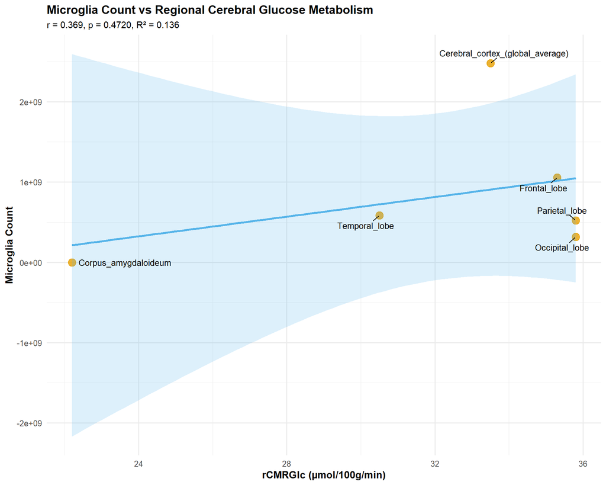

```
## Saved: CellType_NeuronDensity_vs_rCMRGlc.png
##
## === Glia Density vs rCMRGlc ===
## Pearson r = 0.708
## p-value = 0.0752
## 95% CI: [-0.097, 0.953]
## R² = 0.501
## Regression: Glia Density = -1.43e+08 + 6.42e+06 * rCMRGlc
```

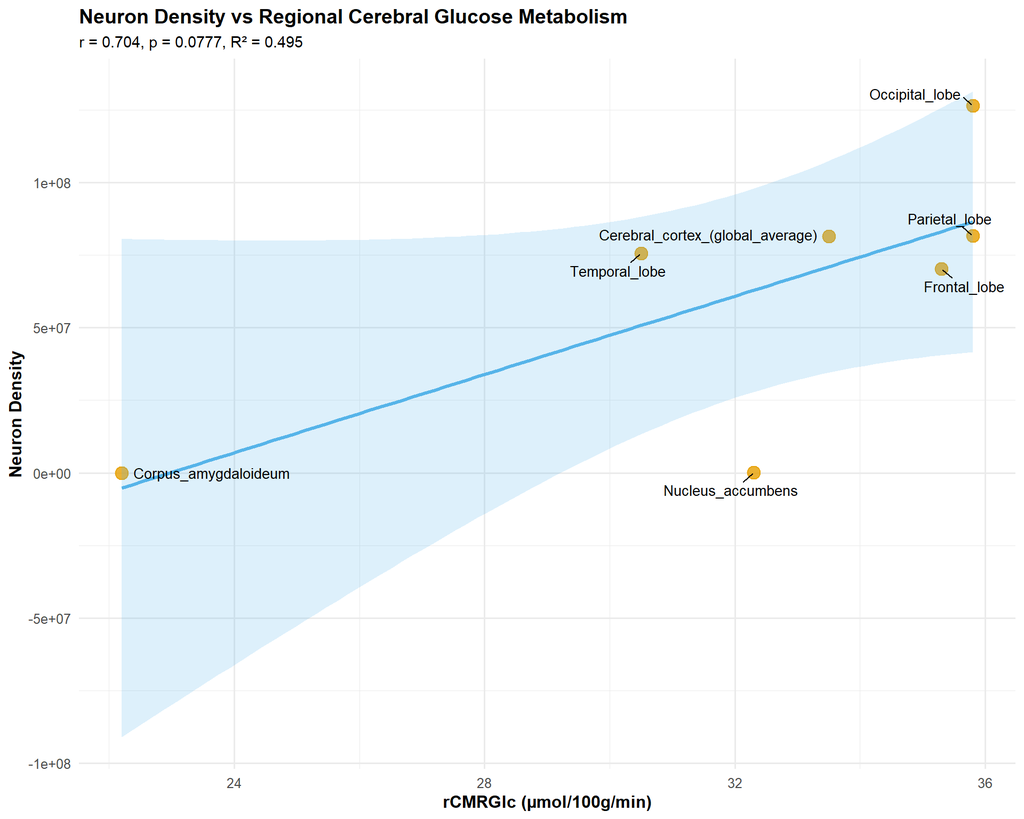

```
## Saved: CellType_GliaDensity_vs_rCMRGlc.png
##
## === Astrocyte Density vs rCMRGlc ===
## Pearson r = 0.967
## p-value = 0.0016
## 95% CI: [0.726, 0.997]
## R² = 0.936
## Regression: Astrocyte Density = -4.11e+07 + 1.94e+06 * rCMRGlc
```

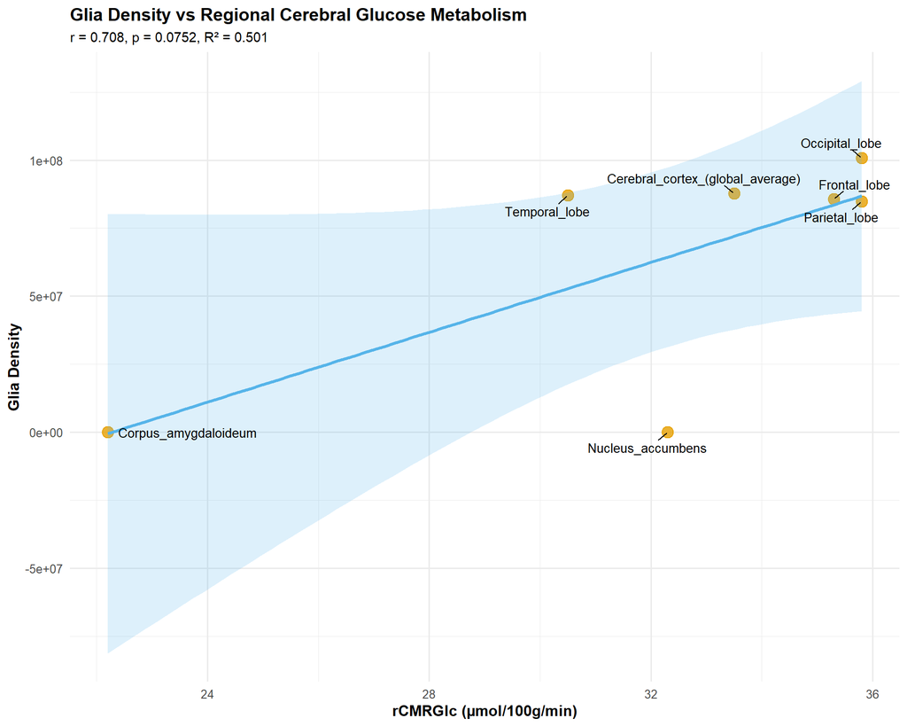

```
## Saved: CellType_AstroDensity_vs_rCMRGlc.png
##
## === Oligodendrocyte Density vs rCMRGlc ===
## Pearson r = 0.897
## p-value = 0.0155
## 95% CI: [0.313, 0.989]
## R² = 0.804
## Regression: Oligodendrocyte Density = -7.19e+07 + 3.51e+06 * rCMRGlc
```

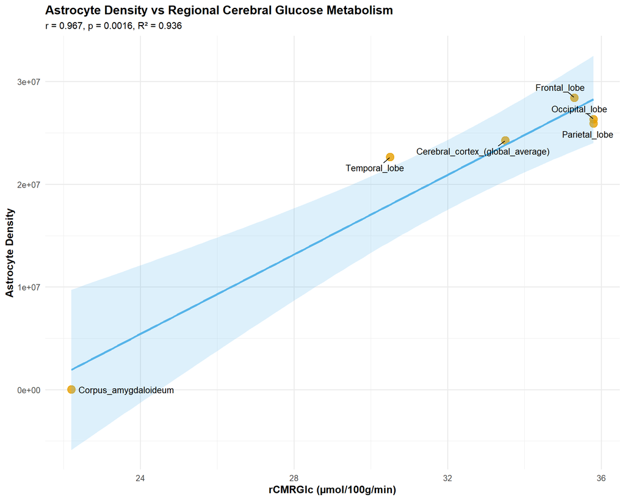

```
## Saved: CellType_OligoDensity_vs_rCMRGlc.png
##
## === Microglia Density vs rCMRGlc ===
## Pearson r = 0.937
## p-value = 0.0059
## 95% CI: [0.523, 0.993]
## R² = 0.878
## Regression: Microglia Density = -1.69e+07 + 8.17e+05 * rCMRGlc
```

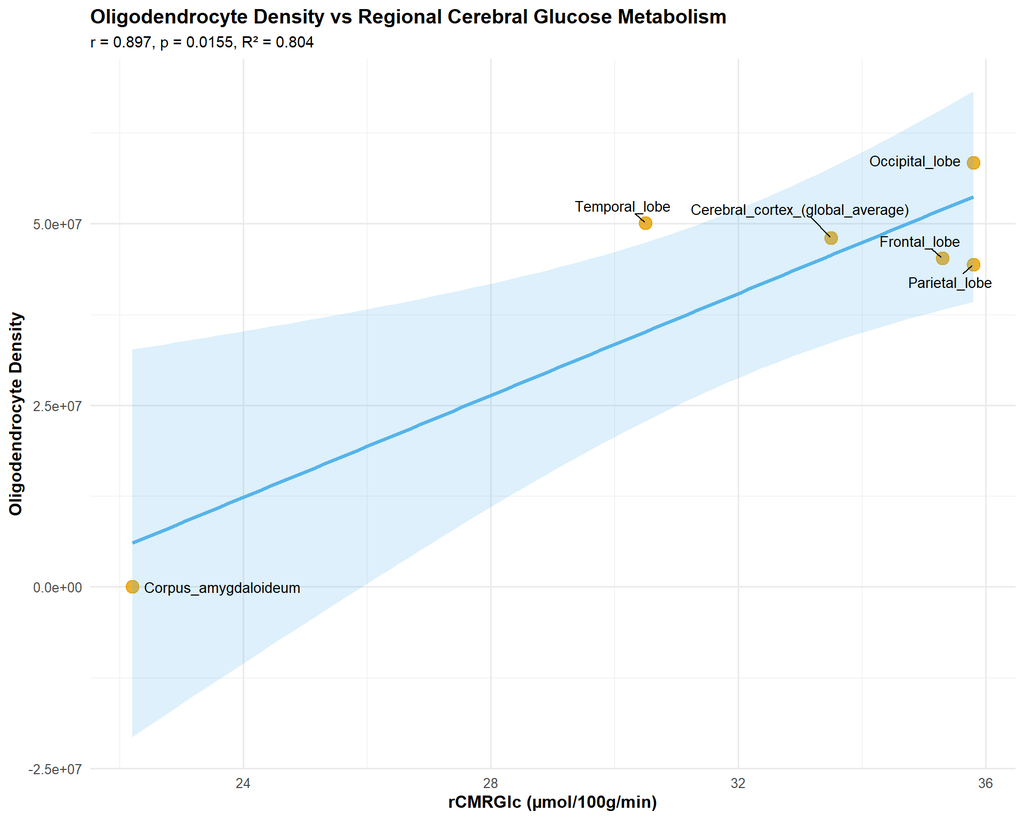

```
## Saved: CellType_MicroDensity_vs_rCMRGlc.png
##
## === Glia:Neuron Density Ratio vs rCMRGlc ===
## Pearson r = -0.924
## p-value = 0.0030
## 95% CI: [-0.989, -0.561]
## R² = 0.853
## Regression: Glia:Neuron Density Ratio = 8.75e+00 + -2.21e-01 * rCMRGlc
```

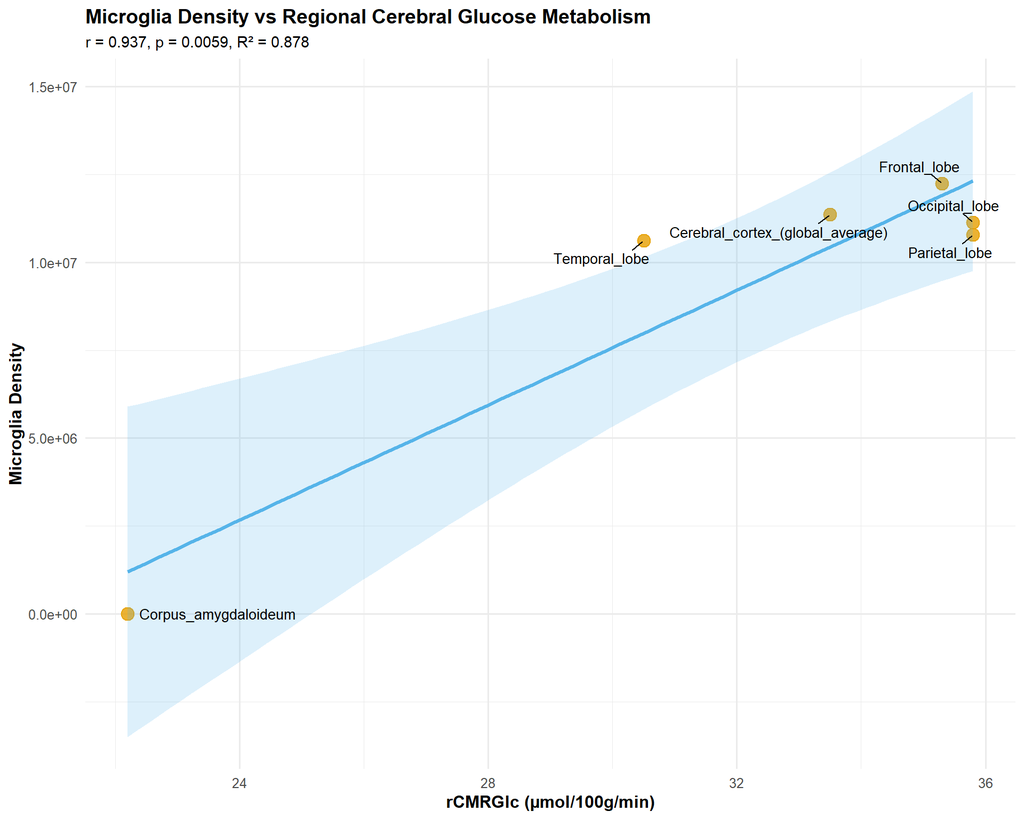

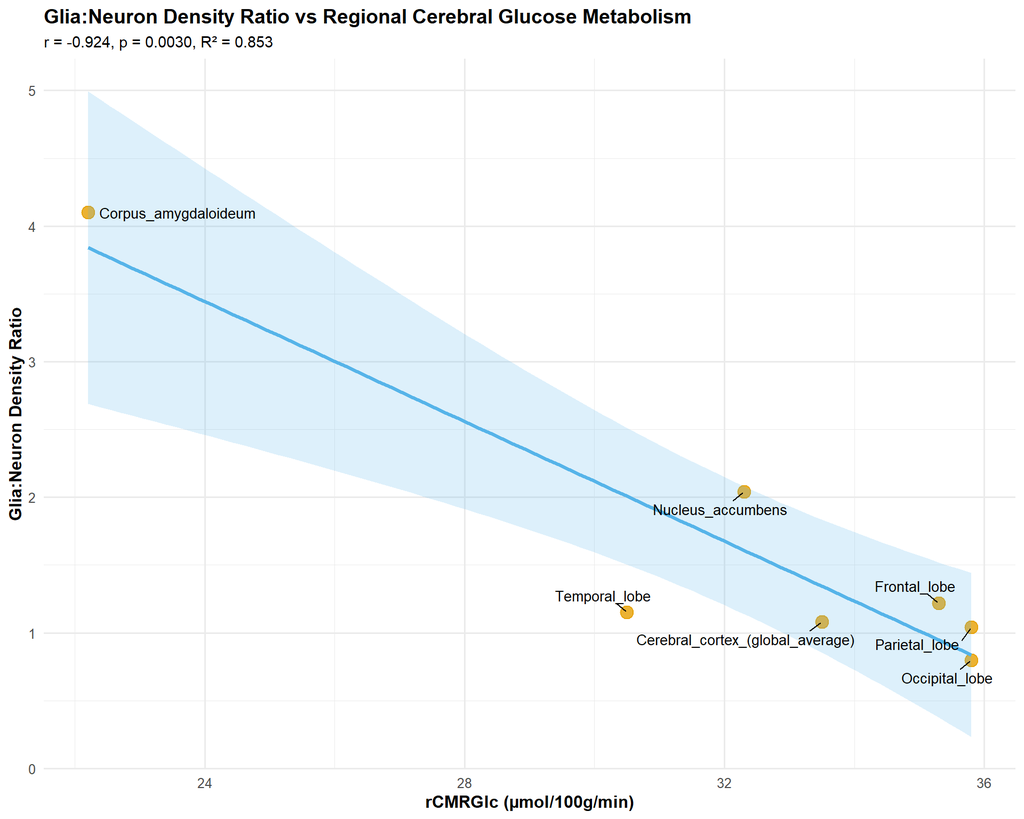

```
## Saved: CellType_GliaNeurRatio_vs_rCMRGlc.png
```

```r
# Define cell types for individual analysis
cell_types <- list(
  Neurons = list(var = "Neuron_N", label = "Neuron Count"),
  Glia = list(var = "Glia_N", label = "Glia Count"),
  Astrocytes = list(var = "Astro_N", label = "Astrocyte Count"),
  Oligodendrocytes = list(var = "Oligo_N", label = "Oligodendrocyte Count"),
  Microglia = list(var = "Microglia_N", label = "Microglia Count"),

  NeuronDensity = list(var = "NeurDensity", label = "Neuron Density"),
  GliaDensity = list(var = "GliaDensity", label = "Glia Density"),
  AstroDensity = list(var = "AstroDensity", label = "Astrocyte Density"),
  OligoDensity = list(var = "OligoDensity", label = "Oligodendrocyte Density"),
  MicroDensity = list(var = "MicroDensity", label = "Microglia Density"),

  GliaNeurRatio = list(var = "GliaNeurDensityRatio", label = "Glia:Neuron Density Ratio")
)

# Color-blind friendly palette
cb_palette <- c("#E69F00", "#56B4E9", "#009E73", "#F0E442",
                "#0072B2", "#D55E00", "#CC79A7", "#999999")

# Create individual plots for each cell type
for (i in seq_along(cell_types)) {
  cell_name <- names(cell_types)[i]
  var_name <- cell_types[[i]]$var
  var_label <- cell_types[[i]]$label

  # Filter data with valid values for both variables
  plot_data <- MetaData[!is.na(MetaData[[var_name]]) &
                        !is.na(MetaData$rCMRGlc), ]

  if (nrow(plot_data) < 3) {
    cat(sprintf("\nSkipping %s - insufficient data (n=%d)\n", cell_name, nrow(plot_data)))
    next
  }

  # Run correlation test
  cor_test <- cor.test(plot_data$rCMRGlc, plot_data[[var_name]],
                       method = "pearson")

  # Run regression
  formula <- as.formula(paste(var_name, "~ rCMRGlc"))
  model <- lm(formula, data = plot_data)
  model_summary <- summary(model)

  # Print results
  cat(sprintf("\n=== %s vs rCMRGlc ===\n", var_label))
  cat(sprintf("Pearson r = %.3f\n", cor_test$estimate))
  cat(sprintf("p-value = %.4f\n", cor_test$p.value))
  cat(sprintf("95%% CI: [%.3f, %.3f]\n",
              cor_test$conf.int[1], cor_test$conf.int[2]))
  cat(sprintf("R² = %.3f\n", model_summary$r.squared))
  cat(sprintf("Regression: %s = %.2e + %.2e * rCMRGlc\n\n",
              var_label, coef(model)[1], coef(model)[2]))

  # Create plot
  p <- ggplot(plot_data, aes(x = rCMRGlc, y = .data[[var_name]])) +
    geom_point(size = 4, color = cb_palette[1], alpha = 0.8) +
    geom_smooth(method = "lm", color = cb_palette[2],
                fill = cb_palette[2], alpha = 0.2, linewidth = 1.2) +
    geom_text_repel(aes(label = Region), size = 3.5,
                    box.padding = 0.5, max.overlaps = 20) +
    labs(title = sprintf("%s vs Regional Cerebral Glucose Metabolism", var_label),
         subtitle = sprintf("r = %.3f, p = %.4f, R² = %.3f",
                          cor_test$estimate, cor_test$p.value,
                          model_summary$r.squared),
         x = "rCMRGlc (µmol/100g/min)",
         y = var_label) +
    theme_minimal(base_size = 12) +
    theme(
      plot.title = element_text(face = "bold", size = 14),
      plot.subtitle = element_text(size = 11),
      axis.title = element_text(face = "bold")
    )

  # Save plot
  filename <- sprintf("CellType_%s_vs_rCMRGlc.png", cell_name)
  ggsave(filename, p, width = 10, height = 8, dpi = 300, bg = "white")

  # Display plot
  print(p)

  cat(sprintf("Saved: %s\n", filename))
}
```

## Summary Table with Correlations

```r
# Create comprehensive summary table
summary_correlations <- data.frame(
  CellType = character(),
  Variable = character(),
  n = integer(),
  r = numeric(),
  p_value = numeric(),
  CI_lower = numeric(),
  CI_upper = numeric(),
  R_squared = numeric(),
  Beta = numeric(),
  stringsAsFactors = FALSE
)

for (i in seq_along(cell_types)) {
  cell_name <- names(cell_types)[i]
  var_name <- cell_types[[i]]$var

  plot_data <- MetaData[!is.na(MetaData[[var_name]]) &
                        !is.na(MetaData$rCMRGlc), ]

  if (nrow(plot_data) >= 3) {
    cor_test <- cor.test(plot_data$rCMRGlc, plot_data[[var_name]])
    formula <- as.formula(paste(var_name, "~ rCMRGlc"))
    model <- lm(formula, data = plot_data)

    summary_correlations <- rbind(summary_correlations, data.frame(
      CellType = cell_name,
      Variable = var_name,
      n = nrow(plot_data),
      r = cor_test$estimate,
      p_value = cor_test$p.value,
      CI_lower = cor_test$conf.int[1],
      CI_upper = cor_test$conf.int[2],
      R_squared = summary(model)$r.squared,
      Beta = coef(model)[2]
    ))
  }
}

# Sort by p-value
summary_correlations <- summary_correlations[order(summary_correlations$p_value), ]

# Print table
print(summary_correlations)
```

```
##               CellType             Variable n          r     p_value    CI_lower   CI_upper R_squared          Beta
## cor7      AstroDensity         AstroDensity 6  0.9674604 0.001571011  0.72562993  0.9965652 0.9359796  1.937320e+06
## cor10    GliaNeurRatio GliaNeurDensityRatio 7 -0.9237763 0.002956045 -0.98889939 -0.5609403 0.8533626 -2.208949e-01
## cor9      MicroDensity         MicroDensity 6  0.9368814 0.005850204  0.52290075  0.9932433 0.8777468  8.168498e+05
## cor8      OligoDensity         OligoDensity 6  0.8966655 0.015465318  0.31253741  0.9887294 0.8040091  3.508139e+06
## cor6       GliaDensity          GliaDensity 7  0.7076963 0.075233422 -0.09712127  0.9529126 0.5008341  6.417747e+06
## cor5     NeuronDensity          NeurDensity 7  0.7036217 0.077694039 -0.10515423  0.9521604 0.4950836  6.739324e+06
## cor2        Astrocytes              Astro_N 6  0.3976509 0.434963187 -0.61113455  0.9141874 0.1581262  1.409325e+08
## cor            Neurons             Neuron_N 6  0.3851664 0.450820768 -0.62028847  0.9117327 0.1483531  4.461199e+08
## cor4         Microglia          Microglia_N 6  0.3686765 0.472040902 -0.63197349  0.9084318 0.1359224  6.132669e+07
## cor1              Glia               Glia_N 6  0.3678621 0.473096885 -0.63253907  0.9082670 0.1353225  4.659555e+08
## cor3  Oligodendrocytes              Oligo_N 6  0.3621364 0.480541129 -0.63648525  0.9071037 0.1311428  2.501445e+08
```

```r
# Save to CSV
write.csv(summary_correlations, "cell_type_correlations_summary.csv", row.names = FALSE)
```

## Multi-panel Figure (Combined Significant Results)

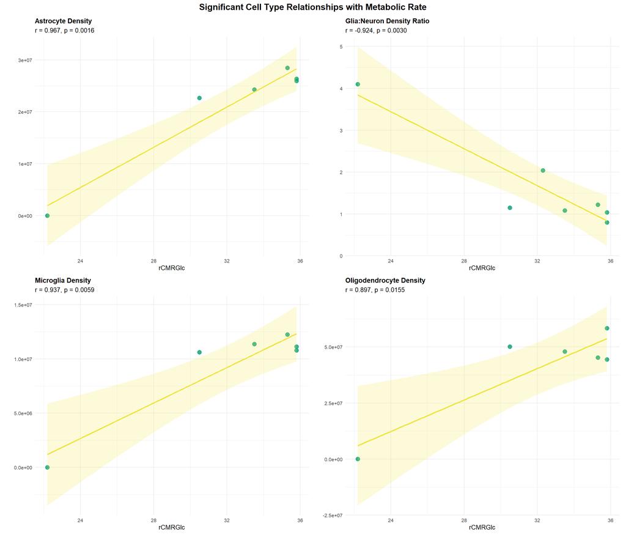

```
##
## Saved: Combined_Significant_CellTypes.png
```

```r
# Create combined multi-panel figure for significant results
significant_vars <- summary_correlations[summary_correlations$p_value < 0.05, "Variable"]

if (length(significant_vars) > 0) {
  plot_list <- list()

  for (var_name in significant_vars) {
    plot_data <- MetaData[!is.na(MetaData[[var_name]]) &
                          !is.na(MetaData$rCMRGlc), ]

    cor_test <- cor.test(plot_data$rCMRGlc, plot_data[[var_name]])

    # Find the label
    var_label <- NA
    for (ct in cell_types) {
      if (ct$var == var_name) {
        var_label <- ct$label
        break
      }
    }

    p <- ggplot(plot_data, aes(x = rCMRGlc, y = .data[[var_name]])) +
      geom_point(size = 3, color = cb_palette[3], alpha = 0.8) +
      geom_smooth(method = "lm", color = cb_palette[4],
                  fill = cb_palette[4], alpha = 0.2) +
      labs(title = var_label,
           subtitle = sprintf("r = %.3f, p = %.4f",
                            cor_test$estimate, cor_test$p.value),
           x = "rCMRGlc", y = "") +
      theme_minimal(base_size = 10) +
      theme(plot.title = element_text(face = "bold", size = 11))

    plot_list[[length(plot_list) + 1]] <- p
  }

  # Combine plots
  combined <- wrap_plots(plot_list, ncol = 2)
  combined <- combined +
    plot_annotation(
      title = "Significant Cell Type Relationships with Metabolic Rate",
      theme = theme(plot.title = element_text(face = "bold", size = 14, hjust = 0.5))
    )

  print(combined)
  ggsave("Combined_Significant_CellTypes.png", combined,
         width = 14, height = 12, dpi = 300, bg = "white")

  cat("\nSaved: Combined_Significant_CellTypes.png\n")
} else {
  cat("\nNo significant relationships found (p < 0.05)\n")
}
```

## Summary

```r
cat("\n", strrep("=", 80), "\n")
cat("ANALYSIS COMPLETE\n")
```

```
## ANALYSIS COMPLETE
```

```r
cat(strrep("=", 80), "\n\n")
cat("FILES CREATED:\n")
```

```
## FILES CREATED:
```

```r
cat("- regression_summary_table.csv (all 18 regressions)\n")
```

```
## - regression_summary_table.csv (all 18 regressions)
```

```r
cat("- regression_full_results.txt (detailed output)\n")
```

```
## - regression_full_results.txt (detailed output)
```

```r
cat("- cell_type_correlations_summary.csv (correlation summary)\n")
```

```
## - cell_type_correlations_summary.csv (correlation summary)
```

```r
cat("- CellType_*.png (11 individual plots)\n")
```

```
## - CellType_*.png (11 individual plots)
```

```r
cat("- Combined_Significant_CellTypes.png (multi-panel figure)\n\n")
```

```
## - Combined_Significant_CellTypes.png (multi-panel figure)
```

```r
cat("SIGNIFICANT RESULTS (p < 0.05):\n")
```

```
## SIGNIFICANT RESULTS (p < 0.05):
```

```r
sig_results <- summary_correlations[summary_correlations$p_value < 0.05, ]
if (nrow(sig_results) > 0) {
  for (i in 1:nrow(sig_results)) {
    cat(sprintf("  %s: r = %.3f, p = %.4f\n",
                sig_results$CellType[i],
                sig_results$r[i],
                sig_results$p_value[i]))
  }
} else {
  cat("  None\n")
}
```

```
##   AstroDensity: r = 0.967, p = 0.0016
##   GliaNeurRatio: r = -0.924, p = 0.0030
##   MicroDensity: r = 0.937, p = 0.0059
##   OligoDensity: r = 0.897, p = 0.0155
```

```r
cat("\n", strrep("=", 80), "\n")
```